# NC Campaign Contributions for 2012 Presidential Election by Steven Yeh

# Data Processing/Transformations

```r
# adding new column: party ------------------------------
nc$party <- ifelse(nc$cand_nm == "Stein, Jill", "Green", ifelse(nc$cand_nm ==
    "Johnson, Gary                      Earl", "Libertarian", ifelse(nc$cand_nm ==
    "Obama,                             Barack", "Democratic", "Republican")))

nc$party <- as.factor(nc$party)

# fixing dates ------------------------------------------
nc$contb_receipt_dt <- as.Date(nc$contb_receipt_dt, "%d-%b-%y")

# fixing zip codes and adding three digit zip column ----
nc$contbr_zip = substr(nc$contbr_zip, 1, 5)
nc$contbr_zip <- as.factor(nc$contbr_zip)
nc$threedigit_zip <- substr(nc$contbr_zip, 1, 3)

# fixing city names -------------------------------------
options(max.print = 5e+05)
nc$contbr_city <- gsub("^WINSTON.*SALEM$", "WINSTON-SALEM", nc$contbr_city)
nc$contbr_city <- gsub("APE", "APEX", nc$contbr_city)
nc$contbr_city <- gsub("APEXX$", "APEX", nc$contbr_city)
nc$contbr_city <- gsub("^A.*VILLE.*", "ASHEVILLE", nc$contbr_city)
nc$contbr_city <- gsub("ASHEVILE", "ASHEVILLE", nc$contbr_city)
nc$contbr_city <- gsub("ASHEVILLLE", "ASHEVILLE", nc$contbr_city)
nc$contbr_city <- gsub("^ATLANTIC B.*", "ATLANTIC BEACH", nc$contbr_city)
nc$contbr_city <- gsub("AUROR", "AURORA", nc$contbr_city)
nc$contbr_city <- gsub("B ELMONT", "BELMONT", nc$contbr_city)
nc$contbr_city <- gsub("BALD HEAD ISL", "BALD HEAD ISLAND", nc$contbr_city)
nc$contbr_city <- gsub("^BLACK M.*", "BLACK MOUNTAIN", nc$contbr_city)
nc$contbr_city <- gsub("BOONE, NC", "BOONE", nc$contbr_city)
nc$contbr_city <- gsub("BROWN SUMMIT", "BROWNS SUMMIT", nc$contbr_city)
nc$contbr_city <- gsub("CHAR.*OT.*", "CHARLOTTE", nc$contbr_city)
nc$contbr_city <- gsub("CHAROLETTE", "CHARLOTTE", nc$contbr_city)
nc$contbr_city <- gsub("CHA.*LOTTE", "CHARLOTTE", nc$contbr_city)
nc$contbr_city <- gsub("^CHAP.*ILL.*", "CHAPEL HILL", nc$contbr_city)
nc$contbr_city <- gsub("CH.*HILL", "CHAPEL HILL", nc$contbr_city)
nc$contbr_city <- gsub("CHAPEL", "CHAPEL HILL", nc$contbr_city)
nc$contbr_city <- gsub("CAPEL HILL", "CHAPEL HILL", nc$contbr_city)
nc$contbr_city <- gsub("^CHAPEL HILL HILL$", "CHAPEL HILL", nc$contbr_city)
nc$contbr_city <- gsub("CAROLINA B.*", "CAROLINA BEACH", nc$contbr_city)
nc$contbr_city <- gsub("CARR.*", "CARRBORO", nc$contbr_city)
nc$contbr_city <- gsub("CARY,", "CARY", nc$contbr_city)
nc$contbr_city <- gsub("CEDAR M.*", "CEDAR MOUNTAIN", nc$contbr_city)
nc$contbr_city <- gsub("CLEMMONS,", "CLEMMONS", nc$contbr_city)
nc$contbr_city <- gsub("CONNELLY.*", "CONNELLY SPRINGS", nc$contbr_city)
nc$contbr_city <- gsub("CORNELUS", "CORNELIUS", nc$contbr_city)
nc$contbr_city <- gsub("DU.*HAM.*", "DURHAM", nc$contbr_city)
nc$contbr_city <- gsub("DYRHAM", "DURHAM", nc$contbr_city)
nc$contbr_city <- gsub("E FLAT ROCK", "EAST FLAT ROCK", nc$contbr_city)
nc$contbr_city <- gsub("EDENTON-", "EDENTON", nc$contbr_city)
nc$contbr_city <- gsub("ELIZABETH CTY", "ELIZABETH CITY", nc$contbr_city)
nc$contbr_city <- gsub("^FORT\\+BRAGG$", "FORT BRAGG", nc$contbr_city)
nc$contbr_city <- gsub(".*QUAY.*VARINA", "FUQUAY-VARINA", nc$contbr_city)
nc$contbr_city <- gsub("GASTONIA.*", "GASTONIA", nc$contbr_city)
nc$contbr_city <- gsub("GRE.*RO.*", "GREENSBORO", nc$contbr_city)
nc$contbr_city <- gsub("GREENVILLLE", "GREENVILLE", nc$contbr_city)
nc$contbr_city <- gsub("HENDERSONV.*", "HENDERSONVILLE", nc$contbr_city)
nc$contbr_city <- gsub("HGILLSBOOROUGH", "HILLSBOROUGH", nc$contbr_city)
nc$contbr_city <- gsub("HICKORY.*", "HICKORY", nc$contbr_city)
nc$contbr_city <- gsub("HIGH P.*", "HIGH POINT", nc$contbr_city)
nc$contbr_city <- gsub("HILLSB.*", "HILLSBOROUGH", nc$contbr_city)
nc$contbr_city <- gsub("HOPE MILLS,", "HOPE MILLS", nc$contbr_city)
nc$contbr_city <- gsub("HUNTER.*", "HUNTERSVILLE", nc$contbr_city)
nc$contbr_city <- gsub("JACKSONVILLE,", "JACKSONVILLE", nc$contbr_city)
nc$contbr_city <- gsub("KERNERVILLE, NC", "KERNERVILLE", nc$contbr_city)
nc$contbr_city <- gsub("KILL DEVIL.*", "KILL DEVIL HILLS", nc$contbr_city)
nc$contbr_city <- gsub("KINGS.*", "KINGS MOUNTAIN", nc$contbr_city)
nc$contbr_city <- gsub("LEICESER", "LEICESTER", nc$contbr_city)
nc$contbr_city <- gsub("MARS.*HILL", "MARS HILL", nc$contbr_city)
nc$contbr_city <- gsub("MIRRISVILLE", "MORRISVILLE", nc$contbr_city)
nc$contbr_city <- gsub("MT.*PLEASANT", "MOUNT PLEASANT", nc$contbr_city)
nc$contbr_city <- gsub("MT.*ULLA", "MOUNT ULLA", nc$contbr_city)
nc$contbr_city <- gsub("MT.*AIRY", "MOUNT AIRY", nc$contbr_city)
nc$contbr_city <- gsub("MT.*GILEAD", "MOUNT GILEAD", nc$contbr_city)
nc$contbr_city <- gsub("NEW.*BERN", "NEW BERN", nc$contbr_city)
nc$contbr_city <- gsub("NORTH TOPSAIL.*", "NORTH TOPSAIL BEACH", nc$contbr_city)
nc$contbr_city <- gsub("OCEAN ISL BCH", "OCEAN ISLE BEACH", nc$contbr_city)
nc$contbr_city <- gsub("PILOT.*", "PILOT MOUNTAIN", nc$contbr_city)
nc$contbr_city <- gsub("PITTSBORRO", "PITTSBORO", nc$contbr_city)
nc$contbr_city <- gsub("RA.*LEI.*", "RALEIGH", nc$contbr_city)
nc$contbr_city <- gsub("RALIEGH", "RALEIGH", nc$contbr_city)
nc$contbr_city <- gsub("REIDSVILLE.*", "REIDSVILLE", nc$contbr_city)
nc$contbr_city <- gsub("ROANOKE RAPID.*", "ROANOKE RAPIDS", nc$contbr_city)
nc$contbr_city <- gsub("ROCKY M.*", "ROCKY MOUNT", nc$contbr_city)
nc$contbr_city <- gsub("SCALY MTN", "SCALY MOUNTAIN", nc$contbr_city)
nc$contbr_city <- gsub("SOUTH.*P.*NES", "SOUTHERN PINES", nc$contbr_city)
nc$contbr_city <- gsub("WAK.*FOREST", "WAKE FOREST", nc$contbr_city)
nc$contbr_city <- gsub("WIL.*MINGTON", "WILMINGTON", nc$contbr_city)
nc$contbr_city <- gsub("WIMGATE", "WINGATE", nc$contbr_city)
nc$contbr_city <- as.factor(nc$contbr_city)
```

# Univariate Plots Section

```
## [1] 156828     20
```

```
##  [1] "cmte_id"           "cand_id"           "cand_nm"
##  [4] "contbr_nm"         "contbr_city"       "contbr_st"
##  [7] "contbr_zip"        "contbr_employer"   "contbr_occupation"
## [10] "contb_receipt_amt" "contb_receipt_dt"  "receipt_desc"
## [13] "memo_cd"           "memo_text"         "form_tp"
## [16] "file_num"          "tran_id"           "election_tp"
## [19] "party"             "threedigit_zip"
```

```
## 'data.frame':    156828 obs. of  20 variables:
##  $ cmte_id          : Factor w/ 14 levels "C00410118","C00431171",..: 7 3 3 3 3 3 3 3 3 3 ...
##  $ cand_id          : Factor w/ 13 levels "P00003608","P20002523",..: 11 12 12 12 12 12 12 12 12 12 ...
##  $ cand_nm          : Factor w/ 13 levels "Bachmann, Michele",..: 7 6 6 6 6 6 6 6 6 6 ...
##  $ contbr_nm        : Factor w/ 34948 levels "AANSTAD, JUDY A.",..: 26321 7475 3960 34806 17911 15819 13432 33974 31187 19314 ...
##  $ contbr_city      : Factor w/ 767 levels "","]","ABERDEEN",..: 214 545 740 584 19 127 282 588 453 195 ...
##  $ contbr_st        : Factor w/ 1 level "NC": 1 1 1 1 1 1 1 1 1 1 ...
##  $ contbr_zip       : Factor w/ 953 levels "","*2704","0",..: 754 265 695 503 916 564 609 504 803 295 ...
##  $ contbr_employer  : Factor w/ 12695 levels ""," COASTAL MEDICAL TRANSPORT, INC",..: 8087 12005 9108 438 1485 9365 9108 6965 4186 3449 ...
##  $ contbr_occupation: Factor w/ 7337 levels "","12K ADVOCATE",..: 5622 7118 5539 6775 6659 441 5539 4612 1054 4612 ...
##  $ contb_receipt_amt: num  87.5 500 175 50 100 1000 50 250 75 100 ...
##  $ contb_receipt_dt : Date, format: "2011-12-06" "2011-09-30" ...
##  $ receipt_desc     : Factor w/ 19 levels "","ATTRIBUTION TO PARTNERS REQUESTED / REDESIGNATION REQUESTED",..: 1 1 1 1 1 1 1 1 1 1 ...
##  $ memo_cd          : Factor w/ 2 levels "","X": 1 1 1 1 1 1 1 1 1 1 ...
##  $ memo_text        : Factor w/ 71 levels "","*","* EARMARKED CONTRIBUTION: SEE BELOW",..: 1 1 1 1 1 1 1 1 1 1 ...
##  $ form_tp          : Factor w/ 3 levels "SA17A","SA18",..: 1 1 1 1 1 1 1 1 1 1 ...
##  $ file_num         : int  779227 756218 756218 756218 756218 756218 756218 756218 756218 756218 ...
##  $ tran_id          : Factor w/ 138767 levels "0079331-0001",..: 3636 7655 7395 7119 6961 7542 6506 7255 7029 6344 ...
##  $ election_tp      : Factor w/ 6 levels "","G2008","G2012",..: 6 6 6 6 6 6 6 6 6 6 ...
##  $ party            : Factor w/ 2 levels "Green","Republican": 2 2 2 2 2 2 2 2 2 2 ...
##  $ threedigit_zip   : chr  "285" "276" "284" "281" ...
```

```
##  [1] "Bachmann, Michele"              "Cain, Herman"
##  [3] "Gingrich, Newt"                 "Huntsman, Jon"
##  [5] "Johnson, Gary Earl"             "Obama, Barack"
##  [7] "Paul, Ron"                      "Pawlenty, Timothy"
##  [9] "Perry, Rick"                    "Roemer, Charles E. 'Buddy' III"
## [11] "Romney, Mitt"                   "Santorum, Rick"
## [13] "Stein, Jill"
```

```
##       cmte_id            cand_id                 cand_nm
##  C00431445:106847   P80003338:106847   Obama, Barack :106847
##  C00431171: 40665   P80003353: 40665   Romney, Mitt  : 40665
##  C00495820:  3909   P80000748:  3909   Paul, Ron     :  3909
##  C00496497:  1510   P60003654:  1510   Gingrich, Newt:  1510
##  C00496034:  1105   P20002721:  1105   Santorum, Rick:  1105
##  C00496067:   558   P00003608:   558   Cain, Herman  :   558
##  (Other)  :   998   (Other)  :   998   (Other)       :   998
##             contbr_nm           contbr_city    contbr_st
##  SNEED, DAVID MR.:   290   CHARLOTTE  :17727   NC:155592
##  VAUGHAN, NGAT   :   202   RALEIGH    :15650
##  BRAZDA, SHIRLEY :   128   DURHAM     :12116
##  JACKSON, PAUL   :   107   CHAPEL HILL:10278
##  SQUIRE, EDWARD  :   105   GREENSBORO : 7122
##  KOPETZ, VINETTE :   104   CARY       : 4979
##  (Other)         :154656   (Other)    :87720
##    contbr_zip                                   contbr_employer
##  27514  :  3491   RETIRED                               :36808
##  27517  :  3361   SELF-EMPLOYED                         :13986
##  27516  :  3261   NOT EMPLOYED                          :11051
##  27705  :  3201   INFORMATION REQUESTED PER BEST EFFORTS: 4189
##  27713  :  2551   INFORMATION REQUESTED                 : 3750
##  27707  :  2494   (Other)                               :85751
##  (Other):137233   NA's                                  :   57
##                               contbr_occupation contb_receipt_amt
##  RETIRED                               :40110   Min.   :    0.12
##  HOMEMAKER                             : 4293   1st Qu.:   25.00
##  PHYSICIAN                             : 4201   Median :   50.00
##  INFORMATION REQUESTED PER BEST EFFORTS: 4000   Mean   :  171.35
##  ATTORNEY                              : 3656   3rd Qu.:  100.00
##  (Other)                               :99319   Max.   :10000.00
##  NA's                                  :   13
##  contb_receipt_dt                                      receipt_desc
##  Min.   :2007-12-21                                          :155199
##  1st Qu.:2012-07-06   REDESIGNATION FROM PRIMARY             :   124
##  Median :2012-09-13   REATTRIBUTION FROM SPOUSE              :    79
##  Mean   :2012-08-04   REATTRIBUTION / REDESIGNATION REQUESTED:    74
##  3rd Qu.:2012-10-16   SEE REATTRIBUTION                      :    46
##  Max.   :2012-12-19   REATTRIBUTED                           :    18
##                       (Other)                                :    52
```

[output cut: 9 more lines]

```
##  Min.   :723511   SA17.769381:     3        :    0   Green     :    30
##  1st Qu.:810684   SA17.781633:     3   G2008:    0   Republican:155562
##  Median :821325   SA17.788551:     3   G2012:88585
##  Mean   :832367   SA17.798308:     3   O2012:   74
##  3rd Qu.:842943   SA17.837858:     3   P2008:    2
##  Max.   :992728   SA17.859296:     3   P2012:66931
##                   (Other)    :155574
##  threedigit_zip
##  Length:155592
##  Class :character
##  Mode  :character
##
##
##
##
```

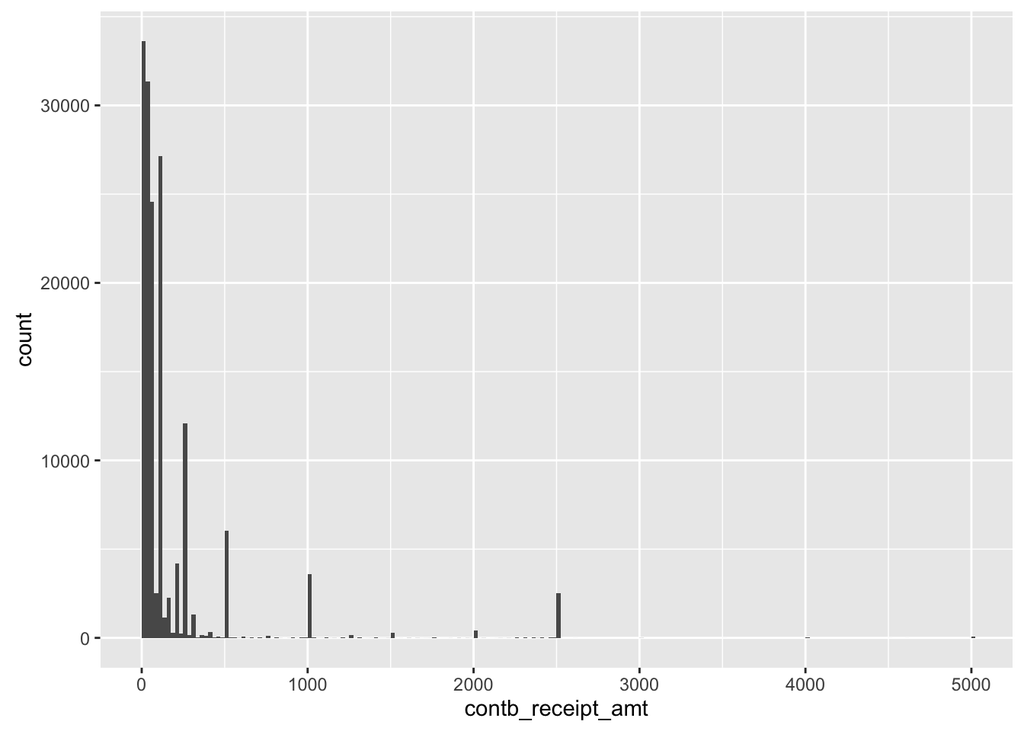

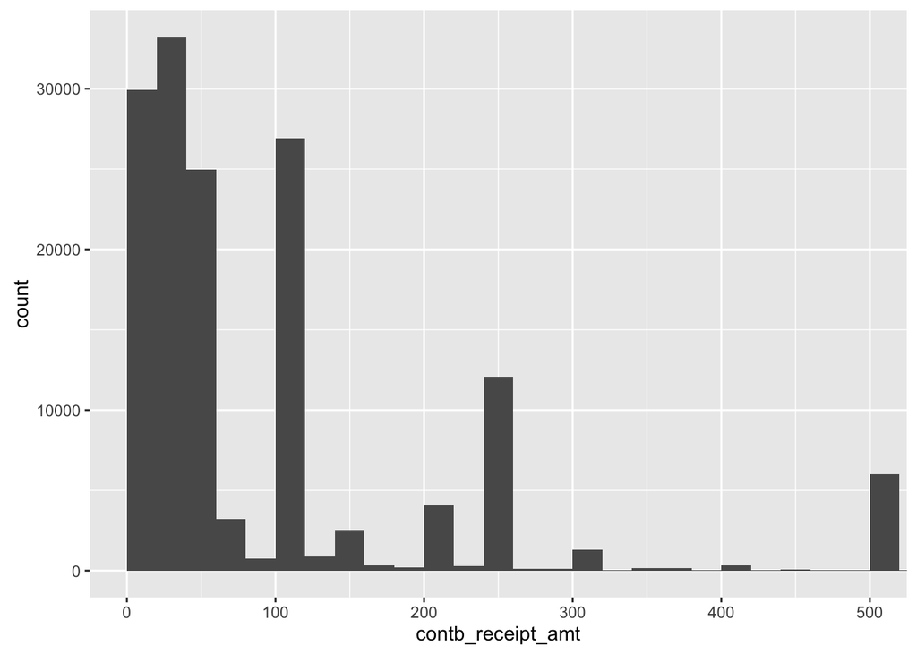

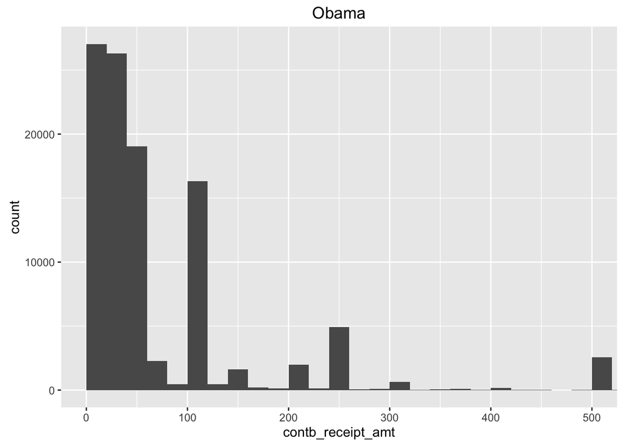

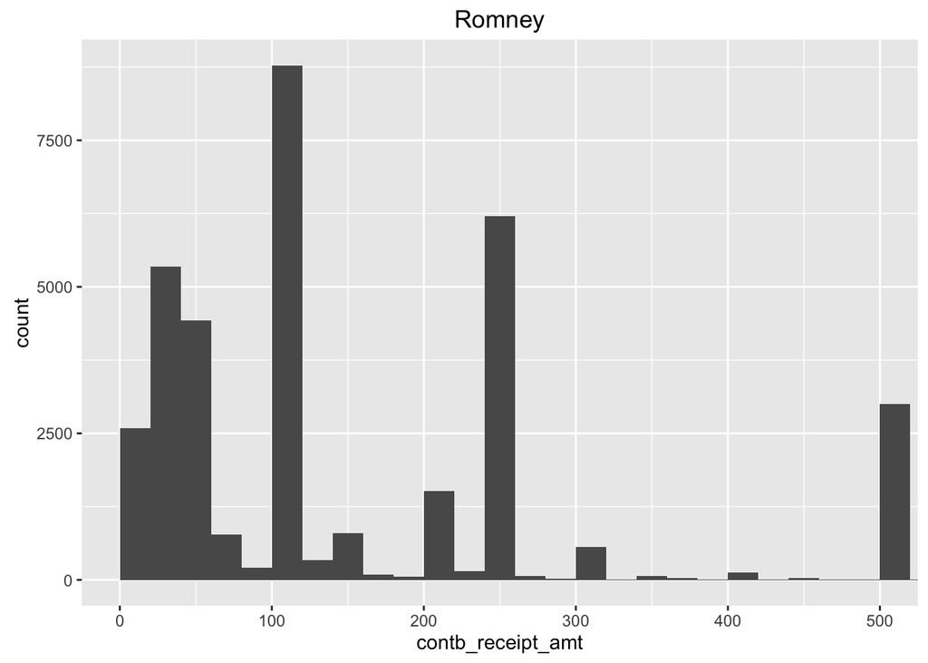

There is only one contributor above $5000. Since the data is long-tailed, I adjusted the binwidth and x-axis in an attempt to gain a better understanding of the contribution distribution. By reducing the binwidth to address bias, the variance increases, but we can see that contributions are somewhat bimodal around $50 and $100. The huge dropoff between values shows how people generally donate values that are regular numbers ($50, $100, $150, $200, $250).

For Obama, we can see that most contributions are well under $500 with a mode below $50. The histogram shows a mode under $50. For Romney, the mode is above $100 with a significant amount of individuals donating around $250.

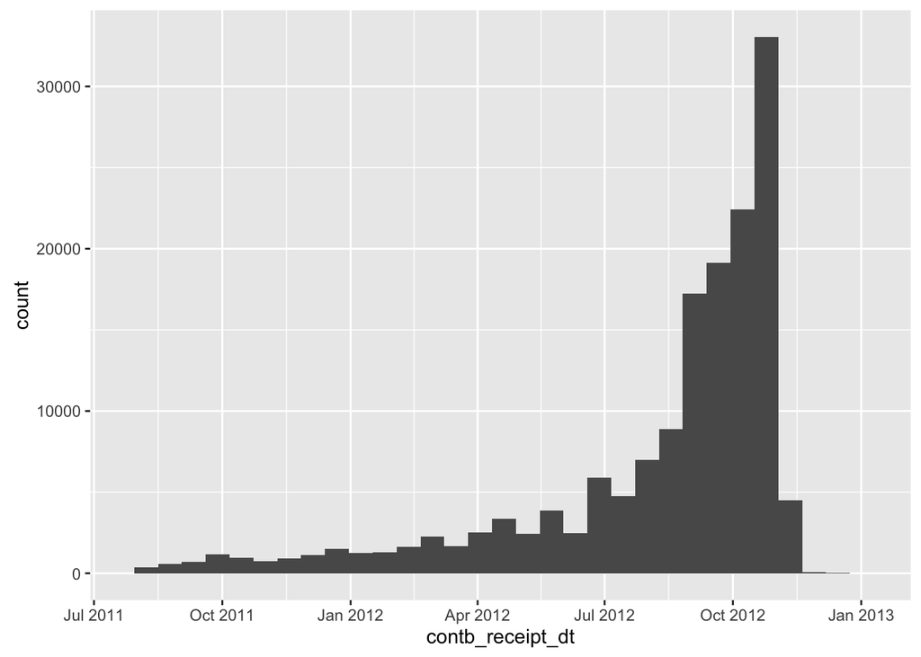

```
## Source: local data frame [629 x 2]
##
##    contb_receipt_dt     n
##              (date) (int)
## 1        2012-10-17  4573
## 2        2012-11-02  3341
## 3        2012-10-23  3129
## 4        2012-08-31  2868
## 5        2012-10-31  2593
## 6        2012-10-22  2514
## 7        2012-09-28  2456
## 8        2012-10-16  2437
## 9        2012-10-26  2429
## 10       2012-10-12  2267
## ..              ...   ...
```

The data is unimodal around October 2012, which was the peak of election season right before Election Day in November. Since the receipt date officially reflects the date the contribution is relinquished from the contributor, the peak in October makes sense; campaigns would certainly utilize the most money around that time of year for the final push.

```
##              Bachmann, Michele                   Cain, Herman
##                            412                            559
##                 Gingrich, Newt                  Huntsman, Jon
##                           1536                             36
##             Johnson, Gary Earl                  Obama, Barack
##                            273                         107631
##                      Paul, Ron              Pawlenty, Timothy
##                           3954                             20
##                    Perry, Rick Roemer, Charles E. 'Buddy' III
##                             90                            146
##                   Romney, Mitt                 Santorum, Rick
##                          41031                           1110
##                    Stein, Jill
##                             30
```

```
## Source: local data frame [2 x 2]
##
##   contb_receipt_amt <= 0      n
##                    (lgl)  (int)
## 1                  FALSE 155592
## 2                   TRUE   1236
```

```
## [1] 0
```

```
## [1] 26656046
```

```
##     Min.  1st Qu.   Median     Mean  3rd Qu.     Max.
##     1.00    19.00    40.00    99.28   100.00 10000.00
```

```
##     Min.  1st Qu.   Median     Mean  3rd Qu.     Max.
##     0.12    25.00    50.00   171.40   100.00 10000.00
```

There exist a good amount of contributors with receipt amounts of either 0 or negative values (1236). These exist to show contribution checks that were bounced or returned. For the sake of calculations, these rows will be excluded. Most campaign contributors in North Carolina gave to Barack Obama (106,847) with Mitt Romney at a distant second (40,665). However, the total amount donated to the Democratic ($10,607,642) is significantly less than that of Republicans ($16,048,404). Doing some simple mathematics, Democrats donated about $99.28 each on average while Republicans averaged about $329.84 per contributor. However, median contribution might be a better measure of central tendency because of the sheer amount of outliers. That being said, Democrats had a median contribution of $40 while Republicans had a median contribution of $100.

```
##   27514   27517   27516   27705   27713   27707   28277   27615   27410
##    3522    3381    3293    3210    2573    2505    2291    2126    1984
##   28211   27612   28226   27613   28803   27106   27609   28804   28210
##    1726    1714    1612    1591    1517    1443    1437    1412    1398
##   27614   27519   27513   27312   27712   27104   27278   27511   27510
##    1381    1357    1353    1319    1285    1245    1237    1209    1196
##   28270   27608   28207   27408   27587   27701   28269   27455   27518
##    1193    1188    1177    1135    1127    1123    1078    1069    1065
##   27607   28173   28205   27858   28078   28036   28031   28374   28409
##    1039    1006     954     941     899     858     857     835     808
##   27604   28405   27539   27603   28739   27606   28105   27610   28209
##     798     794     785     764     761     757     753     730     727
##   28712   28601   28303   27406   28805   28607   28117   27502   28411
##     721     717     716     708     708     703     694     687     686
##   28403   28203   27703   27560   27284   28104   27407   28806   28461
##     679     678     660     653     644     627     626     603     602
##   28562   27540   27103   28202   28311   27616   28387   28412   27403
##     602     597     592     582     576     562     557     551     550
##   27704   28801   27262   27617   27529   28216   28215   27012   27605
##     549     541     535     535     534     533     532     531     527
##   28711   27526   27215   28027   27127   28704   28227   28025   28560
##     526     511     502     499     496     486     479     458     455
## (Other)
##   54780
```

```
## [1] 0.2715339
```

```
## [1] 0.1492436
```

```
## [1] 0.1832767
```

The top five zipcodes for contributors are all from the Triangle area, specifically Durham and Chapel Hill. The total contribution from the Triangle area (Durham, Chapel Hill, Raleigh, and Cary) amounts to $7,239,282.72, which is 27.15% of the total contribution by the state. Charlotte, the most populous city in NC, contributed $3,978,937.01, or about 14.92% of the total contribution. Even if the 10 largest cities comprising of the Charlotte Metropolitan area are included, the contribution ($4,643,388.72, 18.32%) still pales in comparison to the Triangle. The concentration of the state’s top universities (NC State, UNC Chapel Hill, and Duke) in the Triangle area might contribute to the difference.

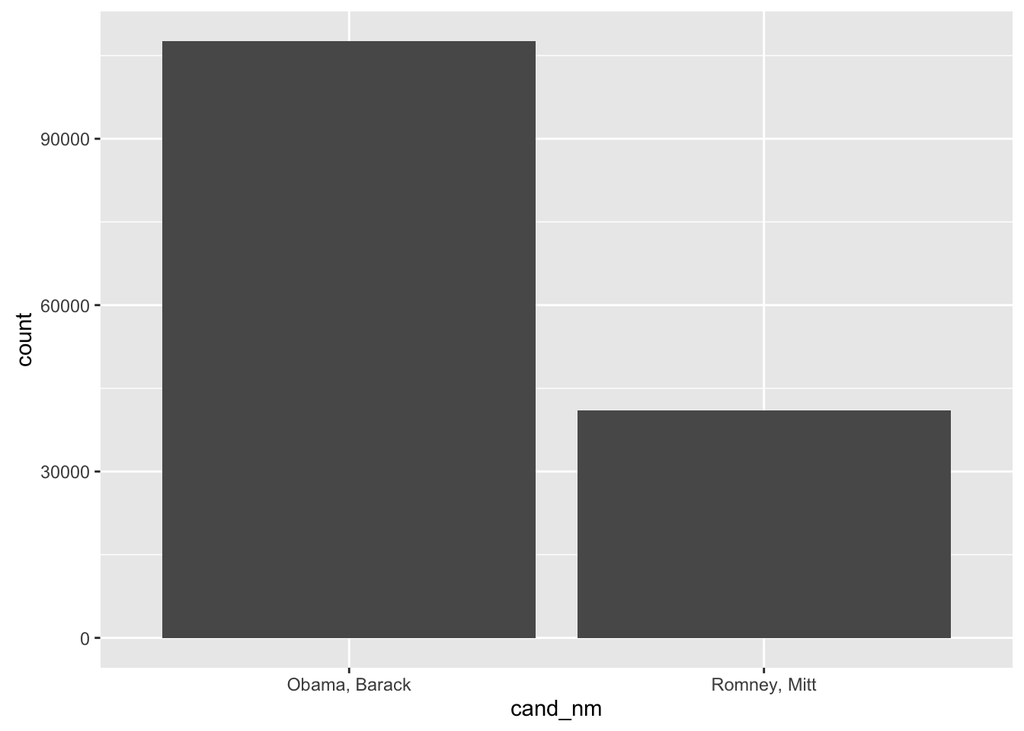

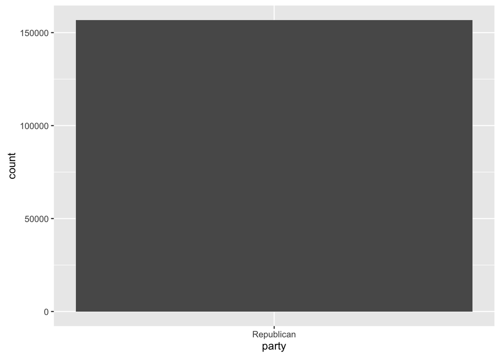

# Univariate Analysis

### What is the structure of your dataset?

The plurality of contributors are retired, self-employed, or unemployed. Campaign contributions are capped at $2,700 per election to a Federal candidate. However, individuals can give up to $5,000 to Political Action Committees (PACs) or up to $10,000 to the State or local party committee.

### What is/are the main feature(s) of interest in your dataset?

The main features in this data set are contribution amount and candidate/party affiliation. I would like to examine which variables determine the amount of contribution towards a specific candidate or political party. This is probably some combination of geographic region (zipcode, city) and the candidate or party him/herself.

### What other features in the dataset do you think will help support your investigation into your feature(s) of interest?

It would be interesting to look at the occupations and employers of contributors who are in the workforce. Perhaps this could also provide some insight as to what type of companies support each candidate. Even though Republican donors gave fewer contributions, the amount contributed was far greater than their Democratic counterparts. Subsetting the data by party will allow for more exploration into this discrepancy.

### Of the features you investigated, were there any unusual distributions? Did you perform any operations on the data to tidy, adjust, or change the form of the data? If so, why did you do this?

Barack Obama dominated campaign contributions, but Mitt Romney won the state with 51% of the popular vote, showing a discrepancy between funding and candidate popularity. There also exist some negative campaign contributions up to -$5,000, which are nonsensical. Zipcodes were often in the extended format, so I amended these to only show 5 digits. In addition, many rows had incorrectly spelled city names (Asheville, Ashevile, Ashville), so I corrected these fields with regex. This would give me a more accurate look into which areas of NC generally supported which candidate. The dates were in a nonstandard format, so I converted them into YYYY-MM-DD format using as.Dates in order to fully utilize this column.

# Bivariate Plots Section

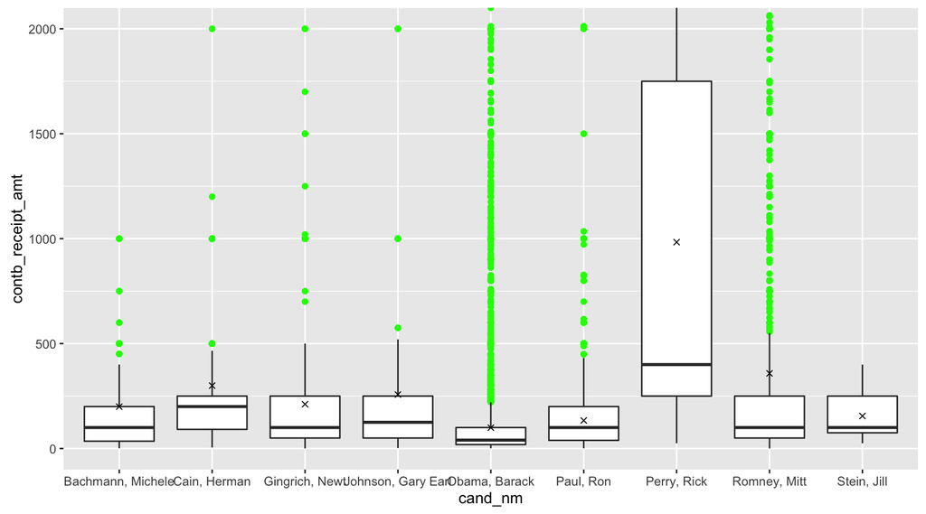

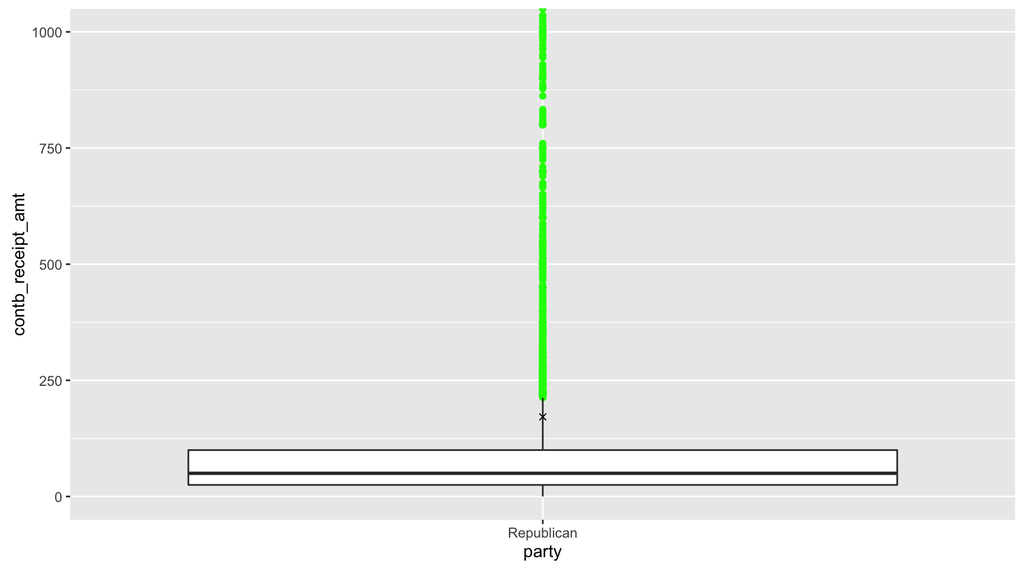

The top two candidates, Obama and Romney have an extraordinary amount of outliers.

```
##    0%   25%   50%   75%  100%
##     1    19    40   100 10000
```

```
## Source: local data frame [2 x 2]
##
##   (contb_receipt_amt > (obamaiqr * 1.5)...     n
##                                      (lgl) (int)
## 1                                    FALSE 96696
## 2                                     TRUE 10935
```

```
##      0%     25%     50%     75%    100%
##    0.12   50.00  100.00  250.00 5000.00
```

```
## Source: local data frame [2 x 2]
##
##   (contb_receipt_amt > (obamaiqr * 1.5)...     n
##                                      (lgl) (int)
## 1                                    FALSE 25362
## 2                                     TRUE 15669
```

```
##   0%  25%  50%  75% 100%
##   25  250  400 1750 5000
```

Obama’s contributors averaged around $99.28 with an Interquartile Range of $81 (100 - 19). There are 10,935 outliers out of the total 106,847 Obama contributors, or who donated greater than $221.50 (1.5 * 81 + 100).

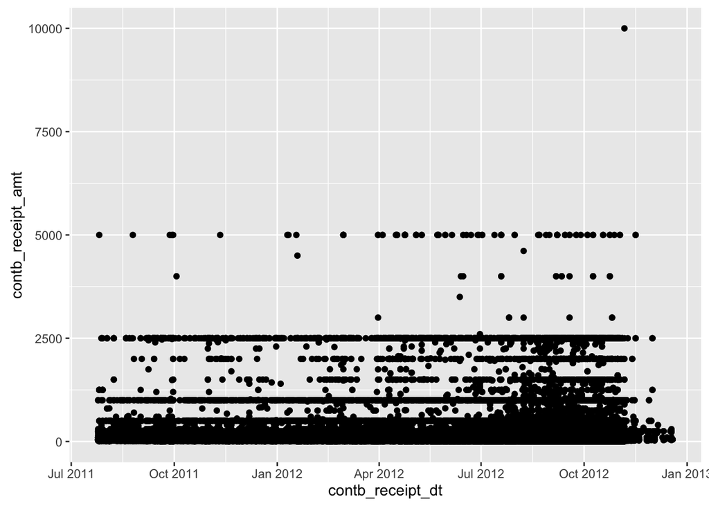

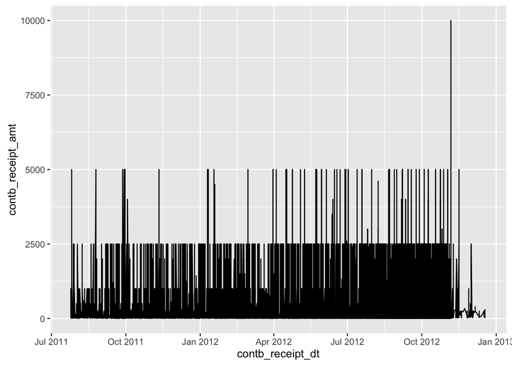

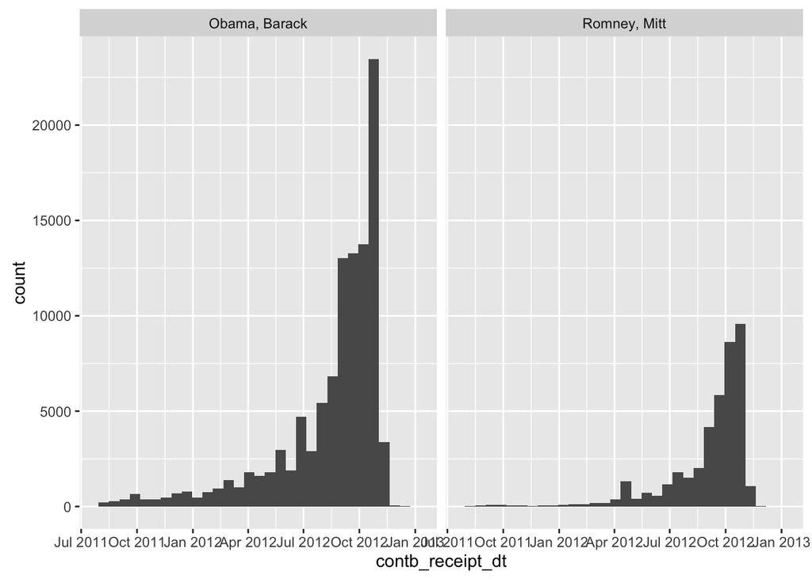

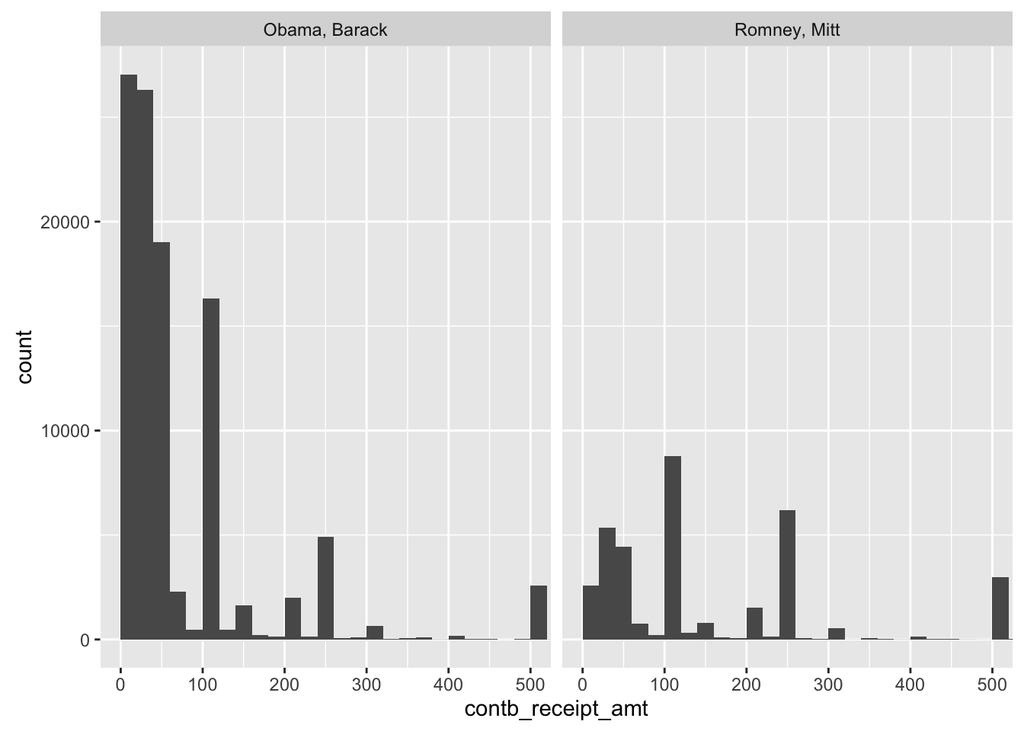

Faceting by candidate reinforces the fact that the median donation for Obama is less than that of Romney.

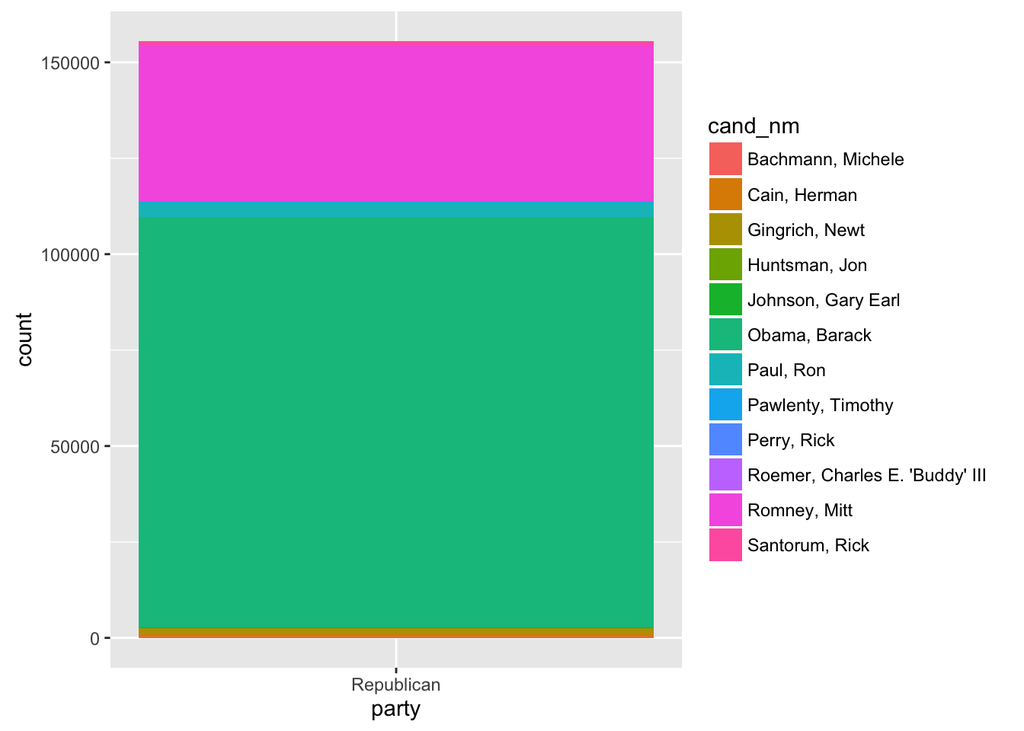

```
## Source: local data frame [13 x 3]
##
##                           cand_nm cont_count  cont_total
##                            (fctr)      (int)       (dbl)
## 1               Bachmann, Michele        412    82199.25
## 2                    Cain, Herman        558   167286.98
## 3                  Gingrich, Newt       1510   318863.98
## 4                   Huntsman, Jon         33    28266.00
## 5              Johnson, Gary Earl        273    70244.00
## 6                   Obama, Barack     106847 10607641.94
## 7                       Paul, Ron       3909   522563.22
## 8               Pawlenty, Timothy         20     9650.00
## 9                     Perry, Rick         86    84575.00
## 10 Roemer, Charles E. 'Buddy' III        144     8488.05
## 11                   Romney, Mitt      40665 14561324.30
## 12                 Santorum, Rick       1105   194943.61
## 13                    Stein, Jill         30     4650.00
```

Obama was campaigning for reelection and was therefore the sole representative for the Democratic Party. Romney eventually edged out the other Republican nominees for the candidacy race, which can be reflected in the chart: his contribution count and total dwarf the rest of the Republicans’ numbers.

```
## Source: local data frame [6 x 3]
##
##   contb_receipt_dt cont_count cont_total
##             (date)      (int)      (dbl)
## 1       2012-04-24        530   569497.5
## 2       2012-07-23        603   307179.5
## 3       2012-07-31       1180   275668.5
## 4       2012-08-27        739   366820.0
## 5       2012-08-31       2868   418976.3
## 6       2012-09-06       2100   299951.8
```

Created a new table that gives the total contribution each day for all candidates. However, the time series has uneven spacing, and it would not make sense to use linear interpolation to transform this data. One would have to somehow build a continuous-time stochastic model or try an advanced algorithm specific to irregularly spaced time-series.

```
## Source: local data frame [20 x 3]
##
##    contbr_zip cont_count cont_total
##        (fctr)      (int)      (dbl)
## 1       28207       1158   746359.9
## 2       28211       1702   720435.9
## 3       27514       3491   624982.6
## 4       27517       3361   604519.5
## 5       27609       1424   535193.8
## 6       27705       3201   492426.3
## 7       28277       2264   459187.8
## 8       27516       3261   447335.7
## 9       27408       1113   442147.5
## 10      27707       2494   419622.1
## 11      27104       1234   406901.8
## 12      27608       1169   391165.0
## 13      27615       2111   386703.3
## 14      27614       1374   372234.6
## 15      28210       1373   362490.5
## 16      28803       1502   360348.3
## 17      28226       1603   359016.3
## 18      27106       1432   323019.5
## 19      27410       1968   317263.5
## 20      27612       1710   299612.8
```

```
## Source: local data frame [20 x 3]
##
##       contbr_city cont_count cont_total
##            (fctr)      (int)      (dbl)
## 1       CHARLOTTE      17727  3978937.0
## 2         RALEIGH      15650  3082240.9
## 3     CHAPEL HILL      10278  1736003.9
## 4          DURHAM      12116  1600856.5
## 5      GREENSBORO       7122  1539059.1
## 6   WINSTON-SALEM       4626   999256.6
## 7            CARY       4979   820181.5
## 8       ASHEVILLE       4970   805009.1
## 9      WILMINGTON       3866   753184.8
## 10   FAYETTEVILLE       2972   494697.1
## 11     HIGH POINT       1083   270061.3
## 12     GREENVILLE       1434   258387.0
## 13      CORNELIUS        843   253807.5
## 14    MOORESVILLE        989   242895.4
## 15 HENDERSONVILLE       1536   223621.0
## 16      PINEHURST        898   213804.7
## 17        HICKORY        839   197335.6
## 18         WAXHAW        923   186835.4
## 19       MATTHEWS       1228   180453.4
## 20    ROCKY MOUNT        622   179045.1
```

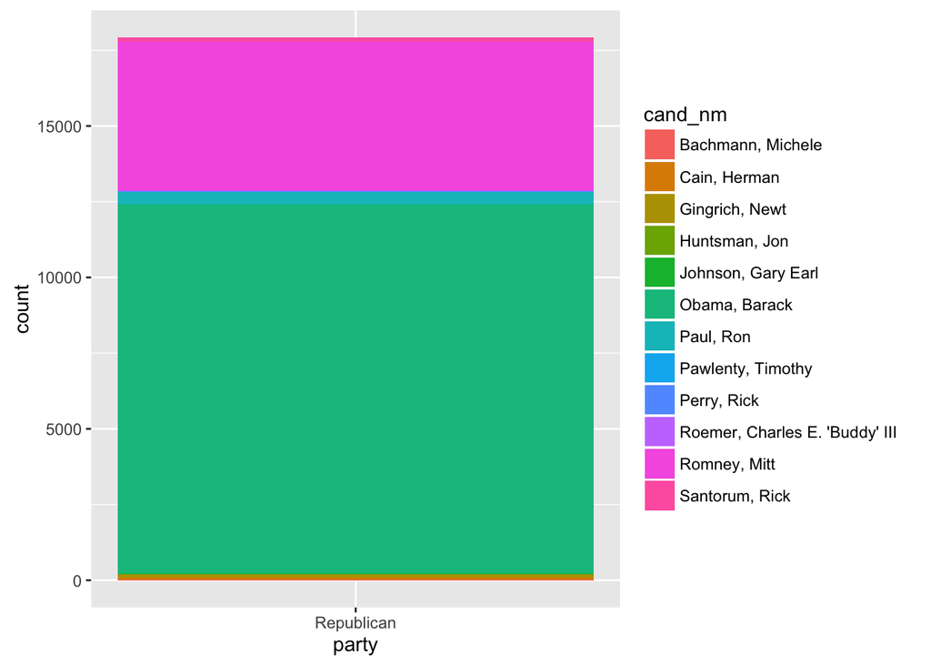

The zipcodes and cities that contributed the most total contribution were located in Charlotte and the Triangle (Chapel Hill, Durham, and Raleigh). This is to be expected since these two are the largest and most populous areas of North Carolina.

```
## Source: local data frame [20 x 4]
##
##                         contbr_occupation cont_count cont_total      mean
##                                    (fctr)      (int)      (dbl)     (dbl)
## 1                                 RETIRED      40110  5934328.9 147.95136
## 2  INFORMATION REQUESTED PER BEST EFFORTS       4000  1976915.3 494.22883
## 3                               HOMEMAKER       4293  1122430.5 261.45597
## 4                               PHYSICIAN       4201  1012233.9 240.95070
## 5                                ATTORNEY       3656   836640.2 228.84033
## 6                   INFORMATION REQUESTED       3354   614351.9 183.16991
## 7                               PROFESSOR       3230   424162.8 131.31975
## 8                               PRESIDENT        772   411719.5 533.31541
## 9                               EXECUTIVE        473   391718.7 828.15799
## 10                             CONSULTANT       2031   305491.7 150.41440
## 11                                   NONE       1346   291663.0 216.68868
## 12                                  OWNER        815   260088.1 319.12652
## 13                               ENGINEER       1717   239274.2 139.35596
## 14                         BUSINESS OWNER        611   226818.8 371.22545
## 15                          SELF-EMPLOYED        987   220506.5 223.41088
## 16                            REAL ESTATE        392   213884.0 545.62258
## 17                                 LAWYER        834   207495.1 248.79508
## 18                                  SALES       1415   201283.4 142.24972
## 19                                    CEO        357   193440.6 541.85034
## 20                                TEACHER       2333   175181.2  75.08837
```

It is interesting to note that a significant chunk of contributors are retired. Ignoring the significant portion of contributors who declined to state their profession, the next top contributors are homemakers. As homemakers most likely do not generate very much income, it is feasible to attribute this high contribution total to those who match their contribution with that of their spouse (this is an available and widely used option in campaign donations). After homemakers are contributors that come from highly esteemed careers such as physicians, attorneys, professors, executives, and presidents.

```
## Source: local data frame [20 x 3]
##
##                           contbr_employer cont_count cont_total
##                                    (fctr)      (int)      (dbl)
## 1                                 RETIRED      36808 5383734.38
## 2                           SELF-EMPLOYED      13986 2187869.73
## 3  INFORMATION REQUESTED PER BEST EFFORTS       4189 2073644.24
## 4                            NOT EMPLOYED      11051 1061578.17
## 5                               HOMEMAKER       2452  905006.10
## 6                   INFORMATION REQUESTED       3750  660829.89
## 7                                    NONE       2203  435487.56
## 8                         DUKE UNIVERSITY       2111  357305.85
## 9                                    SELF       1124  198610.61
## 10                        BANK OF AMERICA        726  119035.06
## 11                                                66  107916.12
## 12           UNIVERSITY OF NORTH CAROLINA        597  101322.90
## 13                            WELLS FARGO        426   89135.02
## 14              LORILLARD TOBACCO COMPANY         62   67121.00
## 15                                    N/A        350   65028.79
## 16                                    IBM        759   63451.63
## 17                          SELF EMPLOYED        316   60619.53
## 18                                    UNC        471   56631.00
## 19            CAROLINAS HEALTHCARE SYSTEM        251   50951.50
## 20                            DUKE ENERGY        221   40892.48
```

Retired contributors are still the top contributors, but self-employed contributors are in second. The term itself is vague, but individuals who comprise this group most likely comprised of small business owners(grocers, restaurants, etc.).

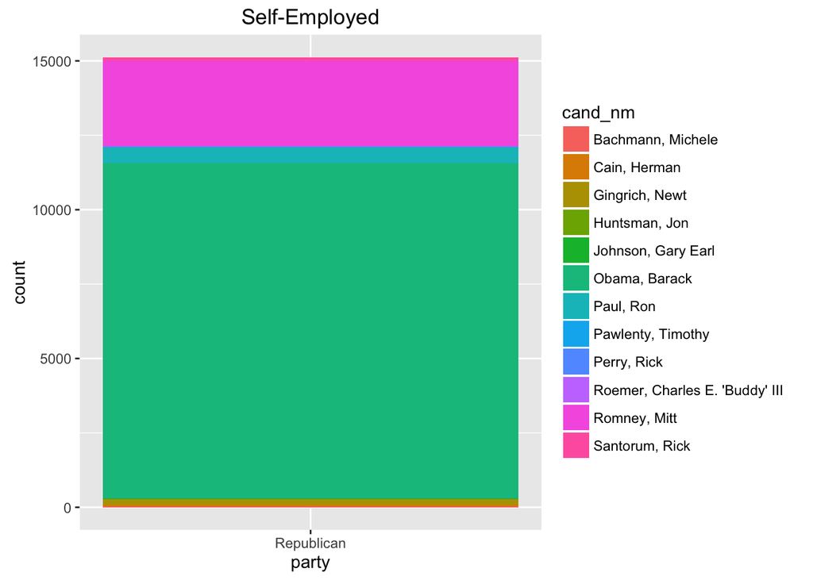

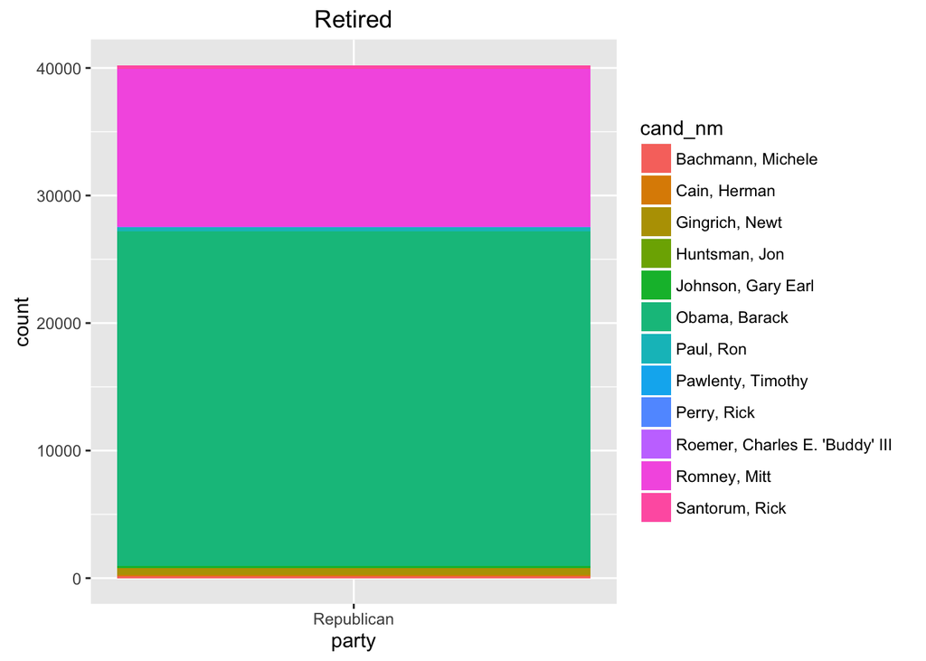

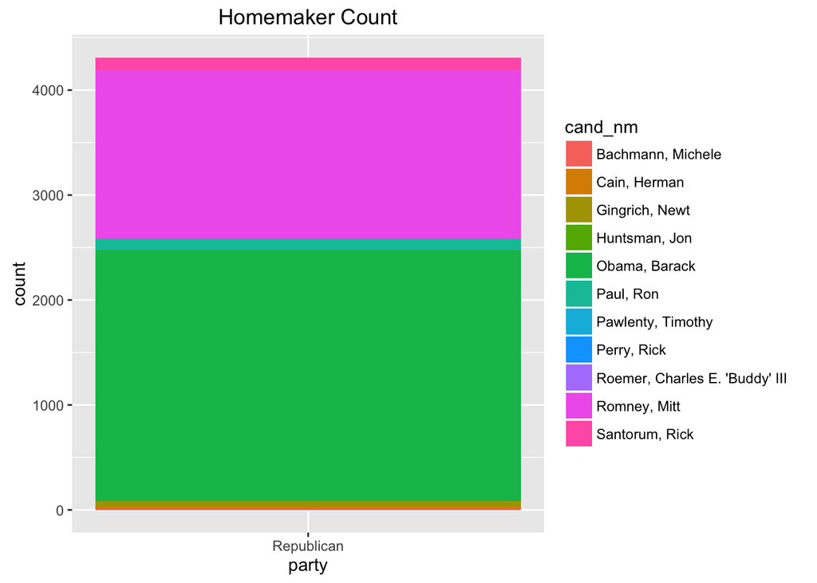

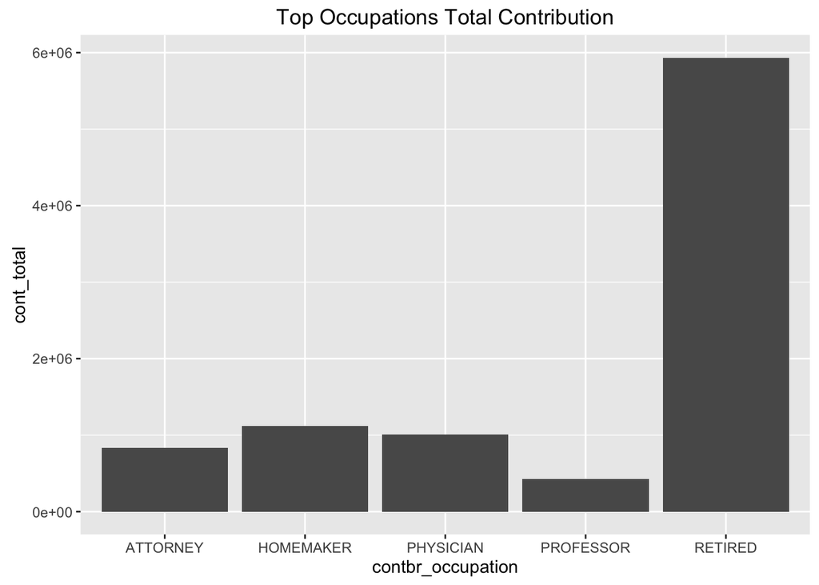

Subsetting the data to just self-employed individuals reveals a chart that is identically-shaped to the chart with complete data. However, subsetting the data to just retired individuals shows that a proportionally greater amount of retired contributors gave to Romney when compared to all occupations. Obama still dominated the contribution count even amongst retired people, but the proportion of contributions is less. Amongst homemakers, the divide between Democratic and Republican is much more evenly split (~2,400 donations for Democrats and just under 2,000 donations for Republicans). The Top Occupations Total Contribution chart shows how much more Retired contributors give (contribution receipt amount) than any other occupation.

```
##
##  Chi-squared test for given probabilities
##
## data:  tbl_zip_test
## X-squared = 90452.03, df = 19, p-value < 2.2e-16
```

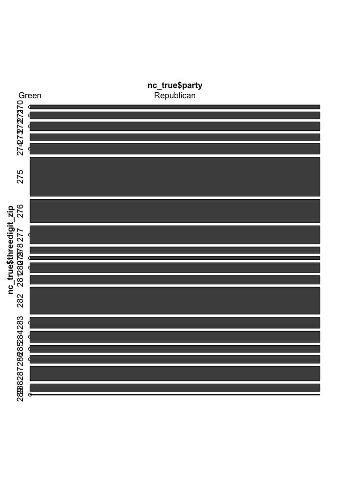

```
##
##  Chi-squared test for given probabilities
##
## data:  tbl_city_test
## X-squared = 4600531, df = 743, p-value < 2.2e-16
```

# Bivariate Analysis

### Talk about some of the relationships you observed in this part of the investigation. How did the feature(s) of interest vary with other features in the dataset?

As most of the variables are nominal (most are simply labels for each contributor), it was infeasible to try and take the correlation of any two variables. However, despite the lack of correlation, there are several observations to be made.

Obama contributors gave less than Romney contributors on average despite having a much higher contribution count. Rick Perry contributors gave an overwhelmingly higher average donation, but the total amount paled in comparison to the two main candidates as Perry did not win the nomination and subsequently dropped out of the race.

The cities and zipcodes with the most amount of contributors were located in the top two metropolitan areas of North Carolina, Charlotte and the Triangle (Raleigh, Durham, Chapel Hill). The distribution of contributions in these cities was identical to the that of the total dataset, with Obama garnering the most contributions by far with Romney in second with significantly less.

### Did you observe any interesting relationships between the other features (not the main feature(s) of interest)?

Looking at occupations and employers, the distribution of contributions is noticeably different with Retired Individuals and Homeowners. Homeowners are almost evenly split between donating to Obama and to Romney, while Retired individiuals have a slightly higher than usual proportion donated to Romney compared to the grand distribution. Retired contributors gave vastly more total money than any other profession.

### What was the strongest relationship you found?

Since campaign receipt was the only numerical (discrete) variable, the only way to measure independence between numerical and categorical (nominal) variables was through a Chi-squared Test of Independence. Running one between party affiliation and zipcode showed that the two variables are definitely not independent of each other (p-value close to 0). A similar test between party affiliation and city produced similar results. However, the strength of these relationships are unknown.

Using ANOVA to evaluate grouped means between contribution receipt and nominal variables (party, zipcode, city) would be infeasible in this case since receipts are discrete, not a continuous variable.

# Multivariate Plots Section

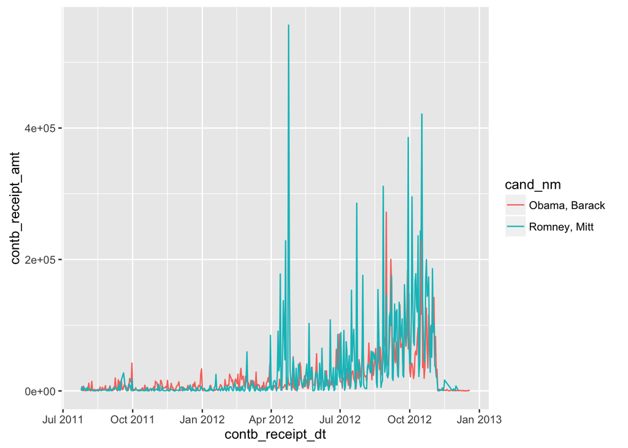

We can see huge spikes of daily contributions in April and the few months leading up to Election Day, especially for Mitt Romney. Maybe looking at cumulative sums would be more interesting than daily sums.

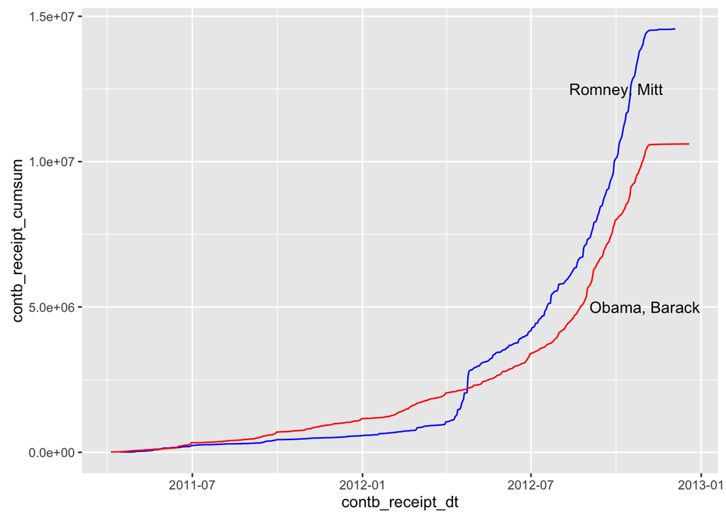

Looking at cumulative sums, we can see that Obama begins the campaign with a higher sum, but is overtaken by Romney around April 2012. Romney came to Charlotte, North Carolina on April 18, 2012 to give a speech, so this could be the cause of the giant spike of contributions in that month.

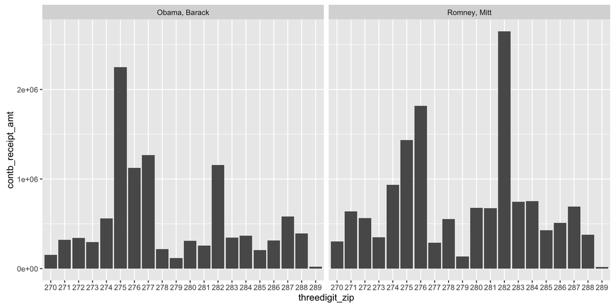

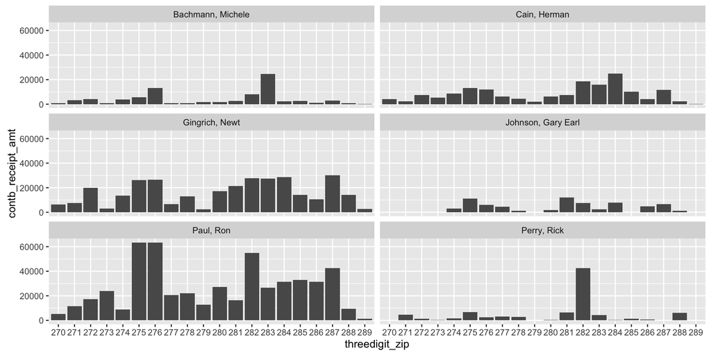

Between Obama and Romney, we can see that the Obama receieved the most donations from the Raleigh area (three-digit code 275 and 276) while Romney received his most donations from Charlotte (280-282). Obama receieved the second most donations from Durham while Romney received one of the smallest amounts by zipcode from Durham (Durham is a much more liberal county than the rest of the state).

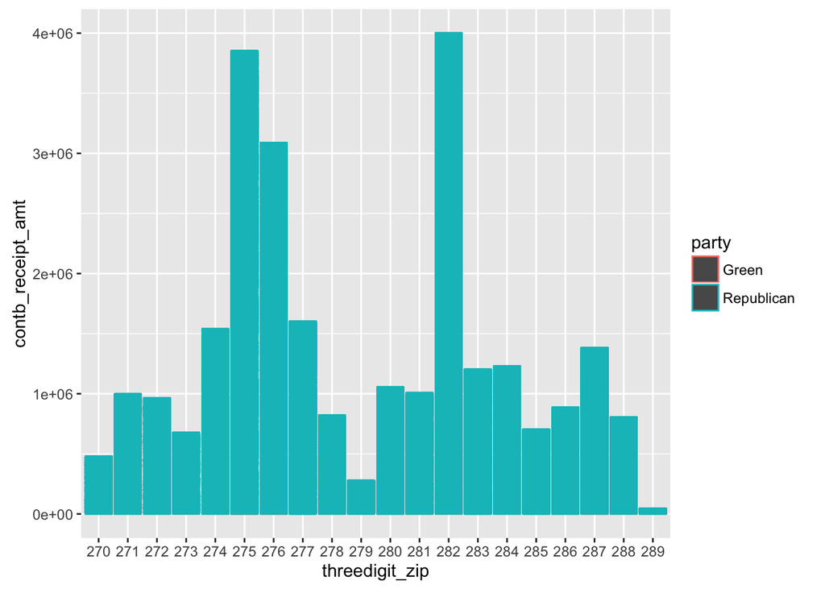

# Multivariate Analysis

### Talk about some of the relationships you observed in this part of the investigation. Were there features that strengthened each other in terms of looking at your feature(s) of interest?

Obama received a higher amount of total contribution amount towards the beginning of the campaign, but the efforts of Romney in the final year, including giving a speech in Charlotte, strengthened his run in the final stretch and caused him to pull ahead in terms of financial support. We could already say for certainty through previous chi-square tests that party is not independent of zipcode and city, and these plots furthered strengthened that claim.

### Were there any interesting or surprising interactions between features?

It was surprising to see how much discrepancy there was between the two main candidates in larger cities. North Carolina has been a swing state in recent years, voting Democratic in 2008 but Republican in 2012. The level of contribution to the two parties in 2012 shows public sentiment shifting towards Romney, whether it be through his extra efforts in the state or Obama’s current term in the office preventing his campaign from reaching the same level of notoriety as in 2008. In 2012, contributors from large cities showed more favor towards Romney as compared to before, even if Raleigh as a whole donated more towards Obama. In smaller zipcodes (with the exception of Durham), the amount of support for Romney overwhelmed that of Obama, probably because small towns in North Carolina largely vote conservative.

### OPTIONAL: Did you create any models with your dataset? Discuss the strengths and limitations of your model.

As stated before, the only possible model would be a time-series model between receipt date and receipt amount. However, the date times are unevenly split, which makes modeling this data very difficult without an advanced algorithm.

# Final Plots and Summary

### Plot One

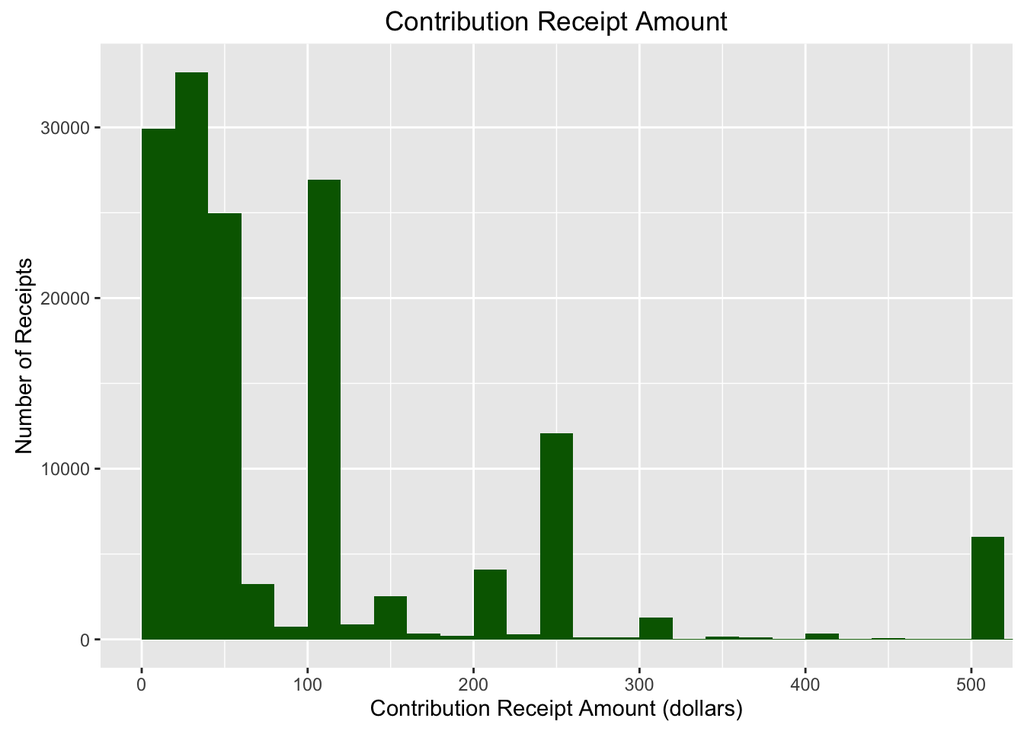

### Description One

Contributions are somewhat bimodal around $50 and $100. Above $50, there are huge dropoffs between $50 increments, which shows how people generally donate values that are regular numbers ($50, $100, $150, $200, $250).

### Plot Two

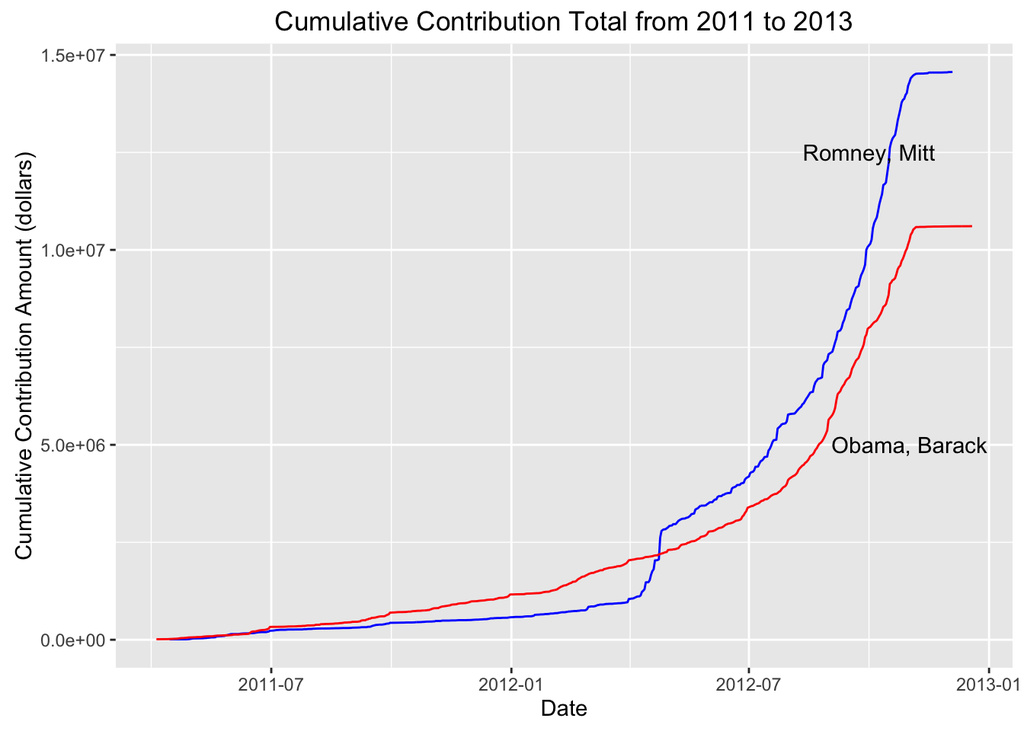

### Plot Three

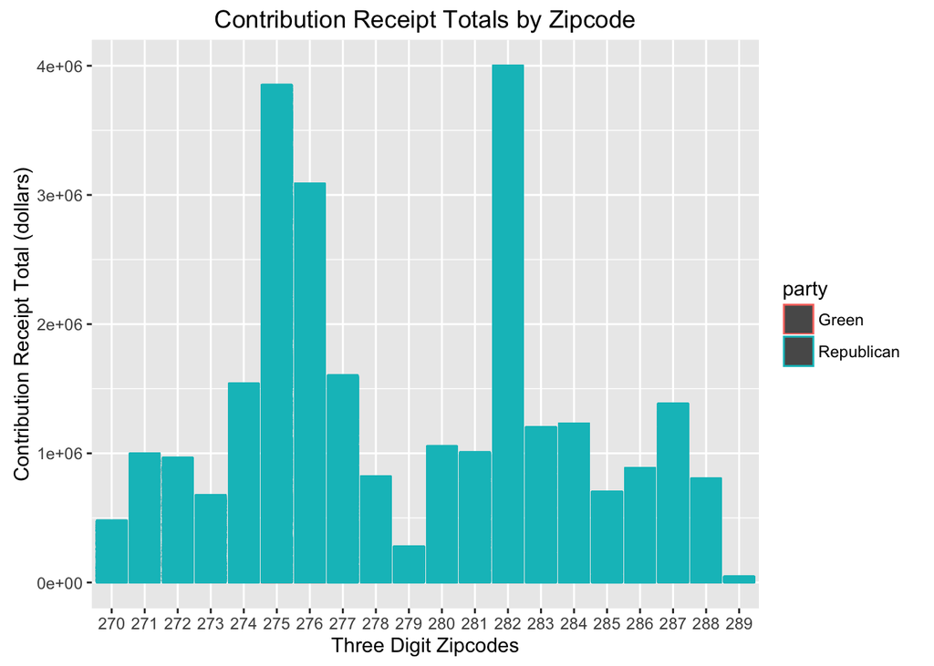

# Reflection

The nc data set contained contribution information on almost 160,000 individuals from the 2012 Presidential Election. Although the variables were mostly categorical (nominal) with the exception of contribution receipt amount and date, there was still much examination to be done regarding donation splits among candidates and parties. Eventually, I explored the amount of financial contribution across several variables and was able to visualize the distribution of contribution receipts over several variables such as party, zipcode, city, and occupation. Unfortunately, this data could not be modeled due to the uneven dates; linear interpolation to fill in between dates would not be a feasible solution. However, through manipulating the data and grouping the data by different variables, I was able to discover just how much more funding and support Mitt Romney and the Republicans had than Obama and the Democrats. In addition, I examined the split of donations across zipcodes and cities of North Carolina and its inhabitants’ occupations to gain a better picture of how the state contributed to each party as a whole and in parts. In the future, for better and more in-depth analyses, it would be interesting to explore additional occupational metrics such as annual salary to see if there existed a relationship between annual salary and contribution amount. Another idea would be to examine each county’s voting distribution to see if voting habits and contributions are similar in a given county. Finally, additional information about contributors themselves such as their age, gender, and population of their listed zipcode or city could illuminate trends in these variables and contribution amounts to better predict which sorts of individuals contribute how much and to which party or candidate.